# Lógica y Pensamiento Científico

Falacias formales

Bogdan G. Popescu

bgpopescu@tec.mx

Tecnologico de Monterrey

# Bienvenida

## Repaso

| Pregunta | Respuesta de la sesión anterior |
| --- | --- |
| ¿Validez vs. verdad? | La lógica válida puede cargar premisas falsas |
| ¿Las tres formas **condicionales** válidas? | Modus ponens, modus tollens, silogismo hipotético |
| ¿Las dos trampas que vieron? | Afirmar el consecuente, negar el antecedente |

# La caja de herramientas formal

## Condiciones necesarias vs. suficientes

“Si perro, entonces mamífero” apunta en **una sola dirección**:

- **Perro es suficiente** para mamífero — ser perro garantiza ser mamífero.
- **Mamífero es necesario** para perro — sin mamífero, no hay perro.

**La regla:**

- hacia adelante (perro → mamífero)
- contrapositiva (no mamífero → no perro).

**Inválido:**

- al revés (mamífero → perro)
- negar las dos (no perro → no mamífero).

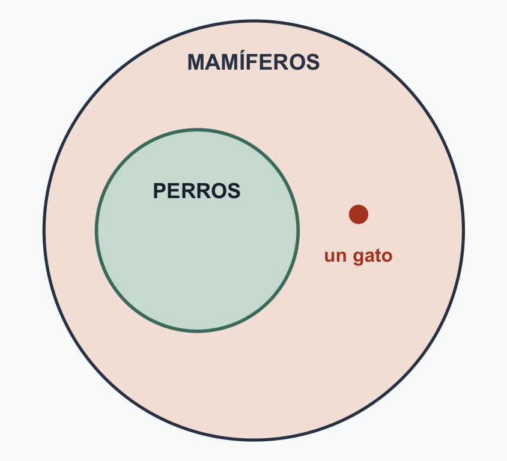

## Condiciones necesarias vs. suficientes

“Si perro, entonces mamífero” apunta en **una sola dirección**:

- **Perro es suficiente** para mamífero — ser perro garantiza ser mamífero.
- **Mamífero es necesario** para perro — sin mamífero, no hay perro.

**una sola dirección**

Regla: **P → Q, no al revés (Q → P).**

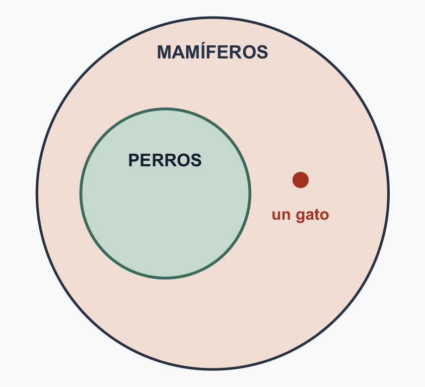

## Las trampas, en la práctica

- *“Si la elección estuviera amañada, habría filas largas. Las filas fueron largas — entonces estuvo amañada.”*
  - **Afirmar el consecuente** — las filas largas no son *suficientes* para probar el fraude.
- *“Si es spam, tiene faltas de ortografía. Este correo no tiene — entonces es seguro.”*
  - **Negar el antecedente** — las faltas no son *necesarias* para el spam; hay estafas bien redactadas.

Necesaria vs. suficiente nombra *por qué* falla cada trampa: cambia lo **suficiente** por lo **necesario**.

# Ejercicio 1 — ¿herramienta o trampa?

¿Herramienta válida o su trampa? Nombren cada una.

- Si llueve, entonces se moja. Llovió. Entonces está mojado.
- Si llueve, entonces se moja. Está mojado. Entonces llovió.
- Si está en París, entonces está en Francia. No está en Francia. Entonces no está en París.
- Si está en París, entonces está en Francia. No está en París. Entonces no está en Francia.

## Ejercicio 1 — respuestas

Cada par comparte **una sola regla**. Lo único que se mueve es la **segunda premisa**.

**Par A — regla: *Si llueve, entonces se moja.***

- *Llovió. Entonces está mojado.* → **modus ponens** · **HERRAMIENTA**
- *Está mojado. Entonces llovió.* → **afirmar el consecuente** · **TRAMPA** — pudo haberlo mojado un aspersor.

**Par B — regla: *Si está en París, entonces está en Francia.***

- *No está en Francia. Entonces no está en París.* → **modus tollens** · **HERRAMIENTA**
- *No está en París. Entonces no está en Francia.* → **negar el antecedente** · **TRAMPA** — Lyon no es París, y sigue estando en Francia.

**Un movimiento legal y un parecido que se rompe.**

## La caja de herramientas de un vistazo

Las cinco formas condicionales — cada herramienta válida junto a la trampa que la imita:

| Nombre | Forma | Veredicto |
| --- | --- | --- |
| modus ponens | Si P, entonces Q. P. entonces Q | VÁLIDO |
| afirmar el consecuente | Si P, entonces Q. Q. entonces P | INVÁLIDO |
| modus tollens | Si P, entonces Q. No Q. entonces No P | VÁLIDO |
| negar el antecedente | Si P, entonces Q. No P. entonces No Q | INVÁLIDO |
| silogismo hipotético | Si P, entonces Q. Si Q, entonces R. entonces Si P, entonces R | VÁLIDO |

Los lógicos catalogan muchas más formas — las familias del “o” y del “todo”, y decenas más allá de ellas. Estas cinco son las que usa el curso. Según Vaughn (2019).

## ¿Y esto para qué? — Saberse las formas no basta

**La receta:**

- premisas ciertas
- conclusión falsa
- un solo caso la refuta.

Entonces, ¿por qué las trampas siguen funcionando, incluso con gente que sabe revisarlas?

Un movimiento equivocado puede **sentirse** válido — y ese sentimiento muchas veces reemplaza la revisión.

**Acto I:** ese sentimiento en su forma más pura.

# Acto I: la respuesta llega primero

## El bat y la pelota

*Aquí no hay herramientas — solo su respuesta inmediata.*

> Un bat y una pelota cuestan $1.10 en total.  
> El bat cuesta $1.00 más que la pelota.  
> **¿Cuánto cuesta la pelota?**

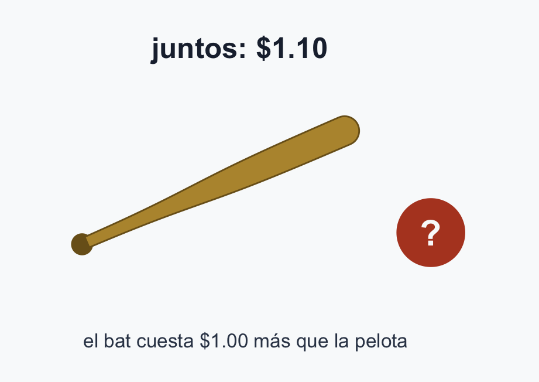

Respuesta correcta: **5 centavos.**

Están en buena compañía:

- mucha gente contesta **10 centavos**
- la respuesta llega **antes** de que corra cualquier revisión.

## Dos renglones de álgebra

Llamemos $x$ a la pelota. Entonces el bat cuesta $x + \$1.00$.

- Juntos cuestan $1.10: $\;x + (x + 1.00) = 1.10$
- Resten el $1.00: $\;2x = 0.10$
- Dividan entre 2: $\;x = 0.05$ — la pelota cuesta **5 centavos**.
- Comprueben: pelota $0.05 + bat $1.05 = **$1.10** ✓
- Casi todos parten $1.10 en $1.00 + 10¢ sin darse cuenta.
- Están contestando una pregunta más fácil que la que les hicieron.

La misma lección que la prueba del contraejemplo: **revisen, no sientan.**

## ¿Y esto para qué? — Sentirse en lo correcto no es estarlo

Una conclusión puede sentirse correcta **antes de razonar.**

Tener las herramientas de revisión no significa que las **usemos.**

## Conclusión

**Una *forma* válida no es una *conclusión* cierta — y un *sentimiento* de seguridad no es una conclusión revisada.** Hoy: la mitad formal.

## Referencias

- Vaughn, L. (2019). *The power of critical thinking: Effective reasoning about ordinary and extraordinary claims* (6.ª ed.). Oxford University Press.